# Go Fish Web Pilot

# Intro

In this experiment, we look at the impact of explaining on hypothesis generation and evaluation processes. Across an *explain* and a *describe* condition, participants are presented with evidence about fishing lure combinations that do and don’t catch fish. They respond to each piece of evidence (either explaining why it did/did not catch fish or describing it) and make a prediction about a similar fishing lure combination.

Once they have seen all the evidence, participants are asked to describe the best rule they were able to come up with about which lure combinations catch fish (hypothesis generation). In a subsequent judgment task, they are presented with eight novel lure combinations and asked which ones will catch fish (test of hypothesis generation).

Finally, participants are asked to evaluate six candidate rules for which lure combinations catch fish, including the target rule (which is consistent with all the evidence), as well as rules that vary in how well they describe the evidence. Upon completion of the task, participants perform a memory test for familiar and novel lure combinations.

**We hypothesize that explaining will make participants more likely to generate the target hypothesis (which is consistent with the virtues of explanation) but that both conditions will evaluate the hypothesis similarly.**

# Results

We piloted with 17 participants across the two conditions.

| Condition | Participants |
| --- | --- |
| Describe | 8 |
| Explain | 9 |

## Hypothesis Generation

First, we look at participant accuracy on the judgment task that followed their hypothesis generation. The plot below shows average accuracy across participants in each condition (error bars indicate one SEM).

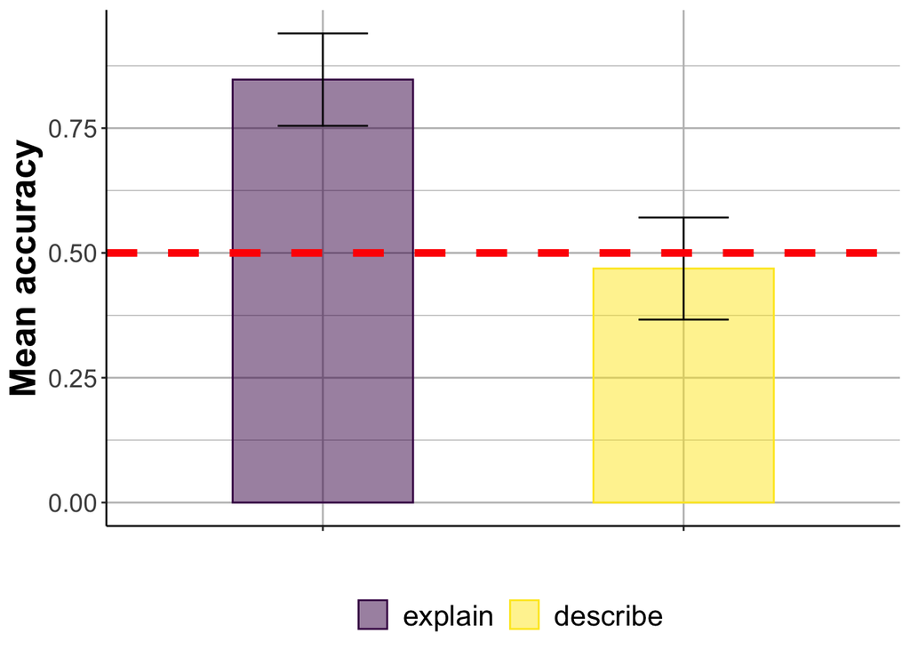

I’ve coded people’s free response answers in the hypothesis generation task based on whether they accurately described the rule for which lure combinations catch fish.

Below is a plot of the percent of accurate responses across conditions (no error bars here because this is based on the raw count of correct hypotheses in each condition).

This shows a decent number of people in the explain condition getting the rule (60-70%) and very few in the control condition getting it (10-15%). I suspect that with more people, we would see these numbers even out a bit since this seems like an extreme difference.

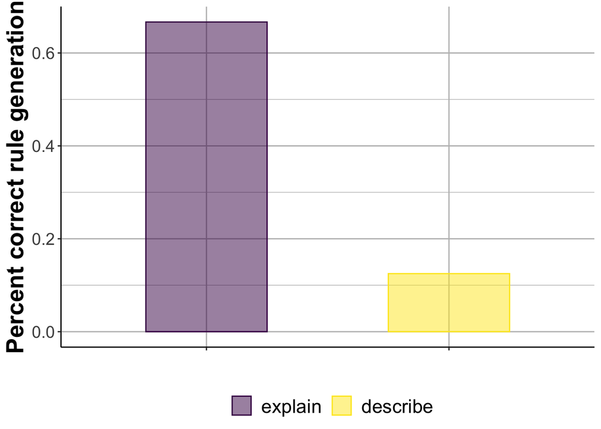

To get a better sense of what these responses look like, below is the raw data along with my coding results (the `Correct` column indicates how I coded the answer).

| Subject | Condition | Response | Correct |
| --- | --- | --- | --- |
| user_1573681812685 | Explain | I noticed that for those with a pointy bottom helped catch fish than the ones with a circular bottom | 1 |
| user_1573678265178 | Explain | I looked in the bottom smaller shapes of the lure to determine my decision. It seem that the shapes that had sharp points caught the fish, and the shape that are round and doesn’t have sharp edges did… | 1 |
| user_1573681828983 | Describe | The single, best rule I used whether the combinations would catch fish was the bottom half of the combination, if it was similar to successful combinations I used it as an indicator of success for cat… | 0 |
| user_1573682158469 | Explain | The single best rule I used was if the lure combinations were of a circular main body and triangle attachment. | 0 |
| user_1573664448979 | Explain | If the lure combination has a pointed bottom, it will catch a fish | 1 |
| user_1573668338160 | Describe | The lower shape must be a shuriken or a rhombus and the the larger top shape can vary. | 1 |
| user_1573678369310 | Describe | Looking at the shape on the bottom of the lure was the best observation | 0 |
| user_1573678954991 | Describe | presence of 1 purple circle in either of the shapes in the combination | 0 |
| user_1573683140886 | Explain | Based on the first observation, I know that fish like color red, yellow and spot on the shape. But at first, I am not quite sure about the rule. So i did not apply it. After few more observations, I a… | 0 |
| user_1573678145931 | Explain | The bottom part of the lure must have more than 1 side (so a square, a rectangle, a triangle for instance). If it does not, then it cannot catch fish in the lake. | 1 |
| user_1573664082430 | Explain | The pattern that I saw the worked for all of the fish included the bottom portion of the lure being a shape that has a defined point, compared to a circle or oval.If the lure had a defined pointed sha… | 1 |
| user_1573678642909 | Describe | I matched up the common colors and shapes of the lures that did work | 0 |
| user_1573668073513 | Explain | Based on the patterns, the fish will bite when the lure has a larger rounded piece and a smaller pointy piece to resemble a fish body, or when the lure has two pointy pieces. The fish did not bite on … | 1 |
| user_1573668222017 | Explain | I looked at shape, size, pattern and color of each lure combination and just based my assumptions off of that and what the fishes previously liked or didn’t like. | 0 |
| user_1573668320610 | Describe | Seeing if the shape on top matched with any previous types of successful lures | 0 |
| user_1573682233340 | Describe | whether there is some similarities with the previous ones that could caught the fish | 0 |
| user_1573664238101 | Describe | I could not come up with a rule | 0 |

Finally, in line with Bonawitz & Griffiths (2010), we can also look at average performance on each prediction to see how participants are performing in their hypothesis generation trial by trial. This data is fairly noisy with so few participants but could be interesting with more subjects.

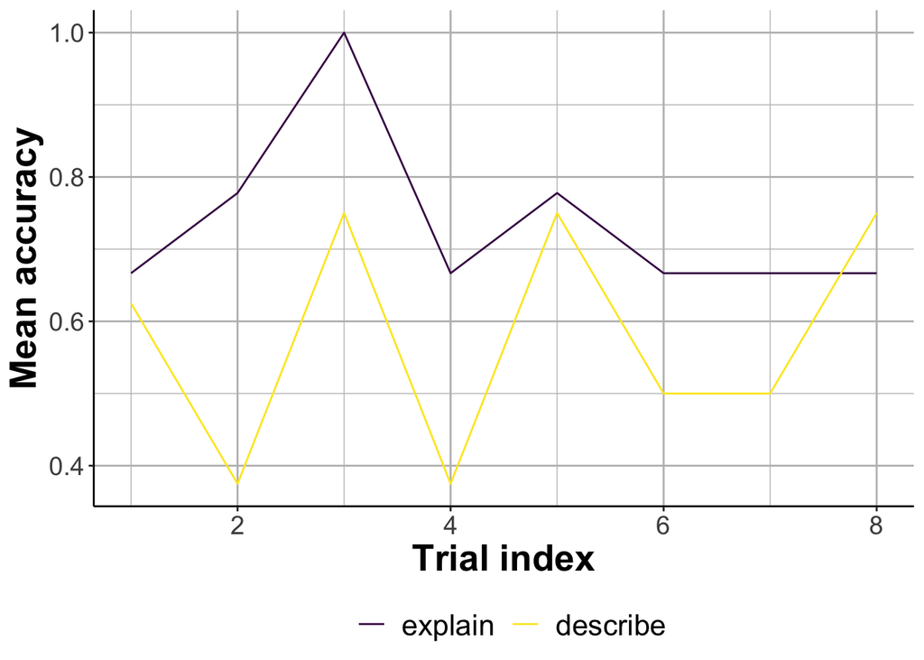

**To summarize, in this pilot data it definitely looks like we have explainers doing a better job generating the abstract “pointy shape” hypothesis.**

## Hypothesis Evaluation

The next thing we look at is how participants in both conditions *evaluate* the target hypothesis, across conditions and relative to the other hypotheses. In the figure below, participant ratings were on a 1-7 scale, with 1 being *“Not good”* and 7 being *“Good”*.

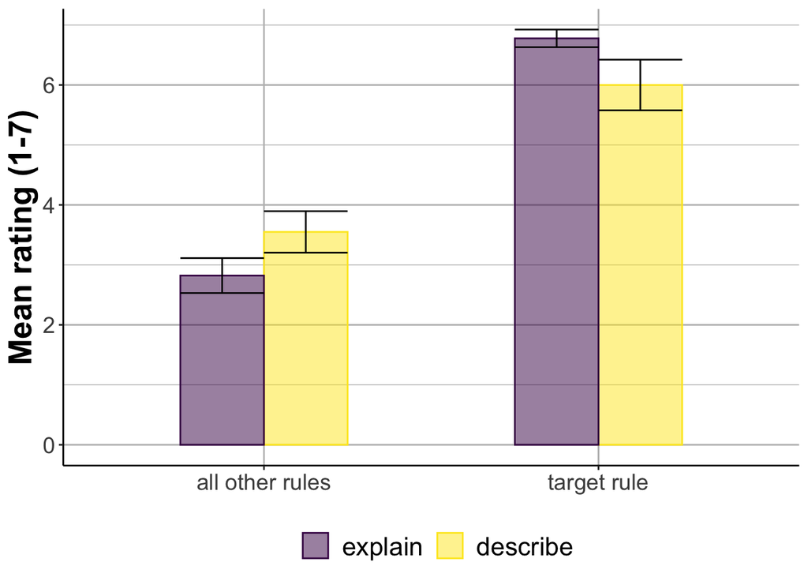

Note also that the target rule statistics above are the mean of all participant ratings for the target rule, while the “all other rules” statistics are the mean and standard error of each subject’s average rating for the five non-target rules (error bars are one standard error of the respective means).

**Here, participants in both conditions evaluate the target explanation as similarly likely (though it appears the explainers may find it slightly better) and much better than competing explanations.**

## Time on Task

An important consideration is whether participants simply spent longer on the explanation task than the control description task and therefore performed better.

Indeed, the figure below suggests that explainers spent longer on the experiment overall, though this difference is not significant (*t* = 1.08, *p* = 0.3).

For future versions, we’ll isolate the time spent on the explanation/description trials rather than the whole experiment. However, it may be worth putting in place additional checks to limit time on task or exploit behaviors that the control describers may be better at.

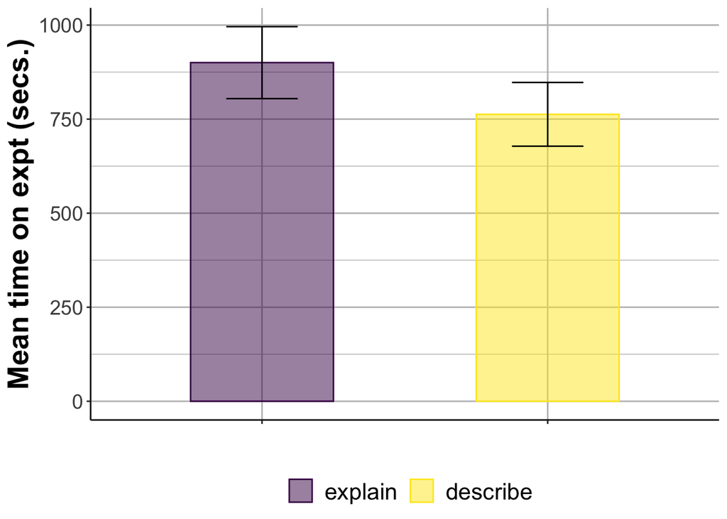

## Memory

Similar to time on task, it’s worth looking at results from the memory task at the end of the experiment to address possible confounds from explainers having a better memory.

In our experiment, we allow participants to view the relevant observations during the evaluation phase of the experiment. While they don’t see them during the hypothesis generation phase, we don’t expect that people are discovering the correct rule from memory during that phase.

In the graph below, we look at accuracy on the memory task. Participants were given a recognition task with four items from the experiment and four that were novel. The four from the experiment were selected to balance whether they appeared as evidence or prediction items and whether they caught fish or not.

In the graph below, the two conditions are similar, suggesting no difference in memory for which stimuli were and were not shown during the experiment.

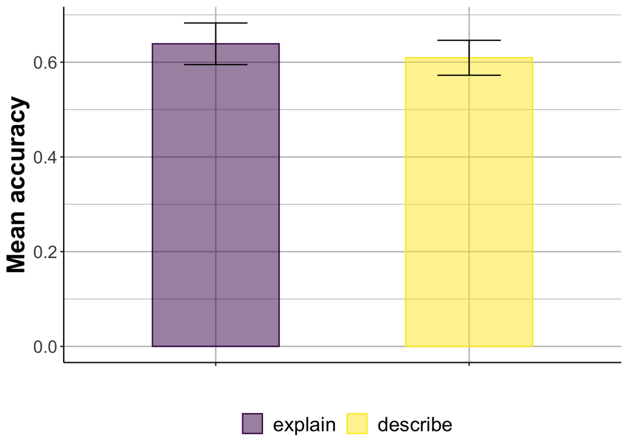